# Shiny Dose Response Relationship

February 27, 2018

## What the App does

This app is designed to help newcomers to pharmacology gain familiarity with the concept of the "**Dose Response Curve**." This sigmoidal curve shows the relationship between a dose of a drug (on the x-axis) versus the Effect (on the y-axis).

The **Dose** is typically shown on a log scale, using a measure of concentration called Molarity (number of Molecules of the drug per Liter).  
The **Effect** is often normalized (0 to 100%), but typically represents a biological outcome (i.e., amount of tension developed by a piece of muscle tissue).

Understanding this relationship allows us to know how much ibuprofen to take when you have a headache, for example.

## Parameters and Units

The formula that describes the dose response curve is given by the equation: \[ Effect(dose) = \frac{Emax * Dose^{h}}{Dose^{h} + EC50^{h}} \] The `h` parameter, not yet defined, is a "steepness factor"" called the **Hill slope** and is unitless  
The `EC50` parameter is the dose of the drug that gives a half-maximal (50%) effect, and shares the units of `dose` which are Molarity (moles/liter). A typical EC50 is around 1 nanomolar = \(1x10^{-9}\) M (molar). For this reason, the x scale units are `log10` of the dose (and represent just the exponent term, i.e. `-9`)  
The `Emax` is the maximum effect level. For the purposes of our demo, this is fixed at 100% (typical of a normalized effect scale)

## Shiny Sliders for parameter inputs

- This Shiny App uses sliders to let the user manipulate the **EC50** and **Hill slope** variables, and see the impacts on the shape of the dose response curve in real time.
- This allows the user to gain familiarity with the impact of these terms. E.g., the Hill slope parameter has an impact on the rate of change of Effect as a function of dose (and therefore, how wide or narrow the range over which the Drug exerts its effect)

## Screenshot

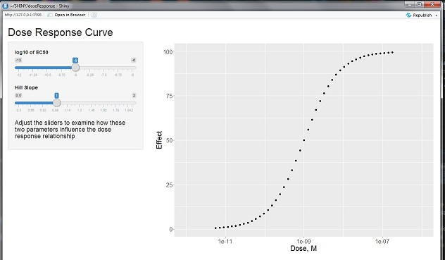

shiny app for manipulating dose response curve parameters